# Risky Counties

December 1, 2016

## Counties

Low Risk:

- Fairbanks, AK
- Finney, KS
- La Plata, CO
- Madison, AL
- Yuma, AZ

High Risk:

- Rapides, LA

## There is Another Side to The Problem

It is estimated that each year in the United States:

- 326,200 people experience EMS-assessed out-of-hospital cardiac arrests
- 209,000 people are treated for in-hospital cardiac arrest.
- Approximately 10.6% of people who experience nontraumatic EMS-treated cardiac arrest survive to discharge

## Time is of The Essence

Brain death and permanent death begin to occur in 4-6 minutes after someone experiences cardiac arrest.

EMS response time is a decisive factor in out-of-hospital cardiac arrests.

- response time data is not recorded on a state or national level
- it is left up to individual EMS agencies or counties to make decide what to keep track of

## EMS Response Times in Los Angeles

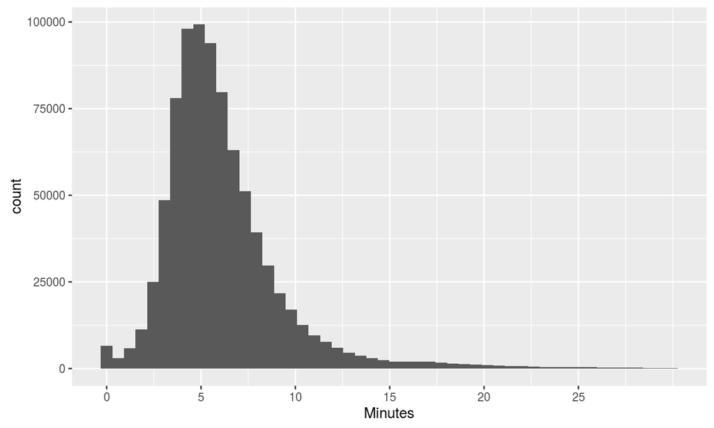

## EMS Response Times in New York

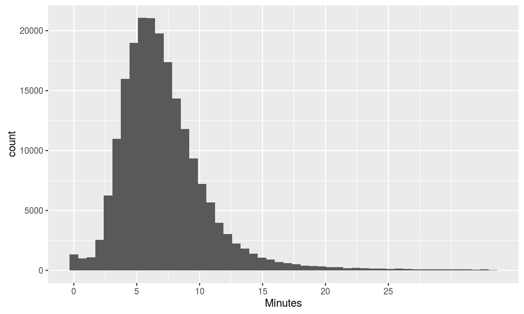

## Complications Post Surgery

## Complications Post Surgery

- Severe Blood Clots

## Complications Post Surgery

- Severe Blood Clots
- Blood Stream Infection

## Complications Post Surgery

- Severe Blood Clots
- Blood Stream Infection
- Infection of Catheter

## Complications Post Surgery

- Severe Blood Clots
- Blood Stream Infection
- Infection of Catheter
- Other Serious Complications

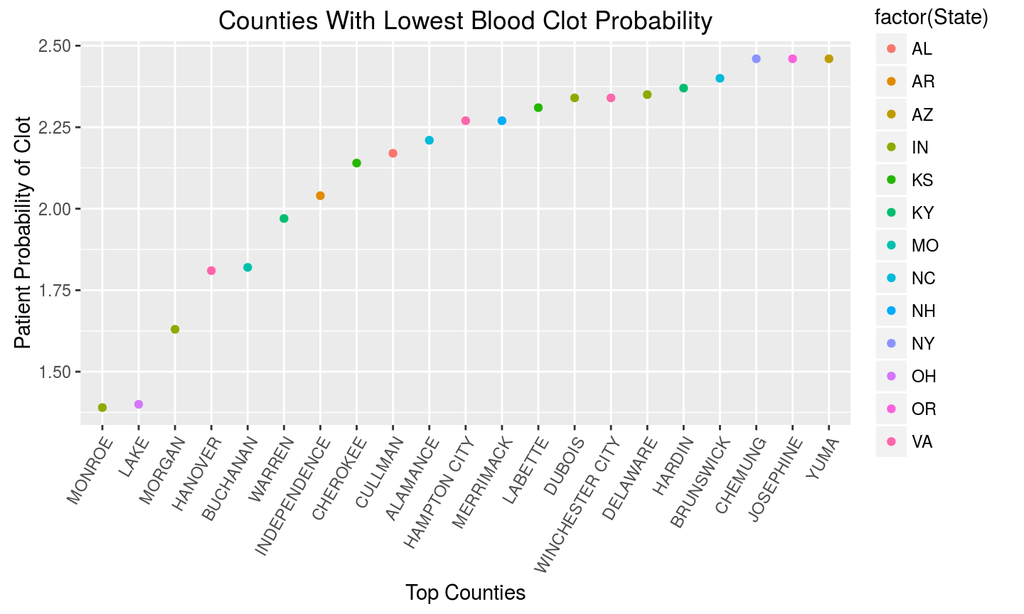

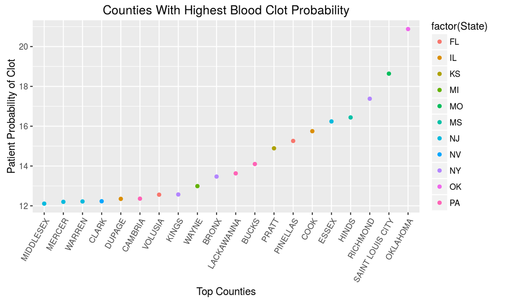

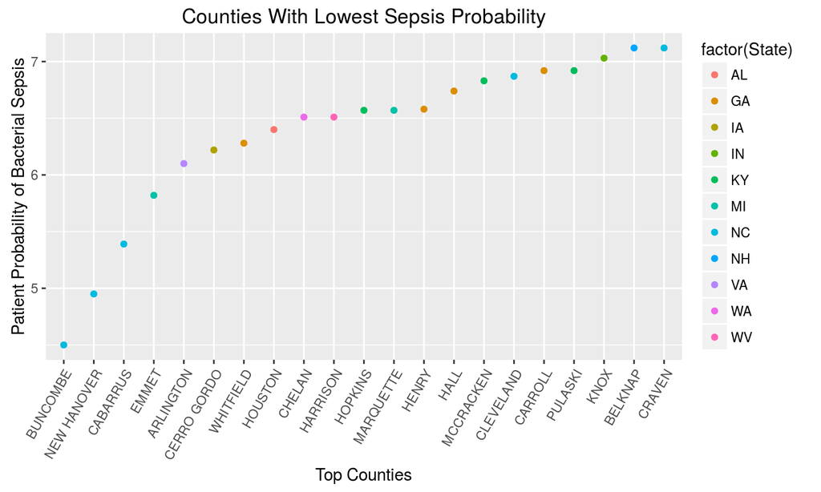

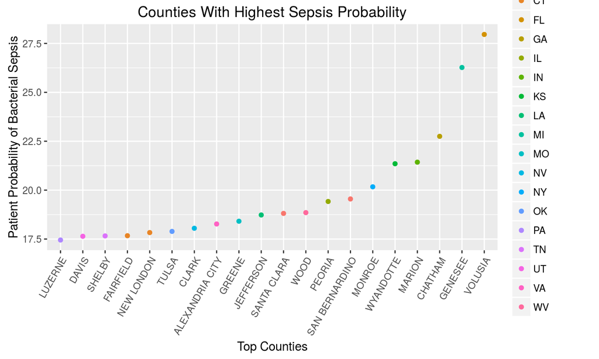

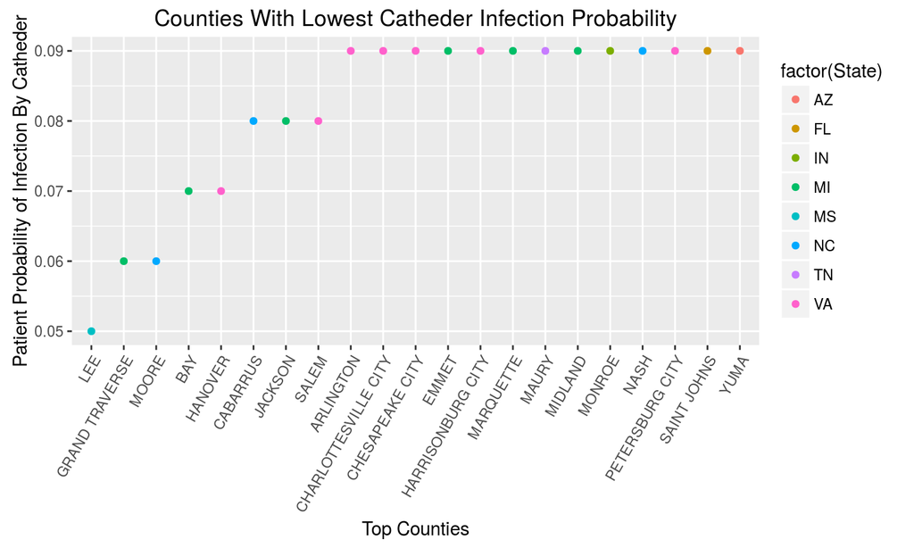

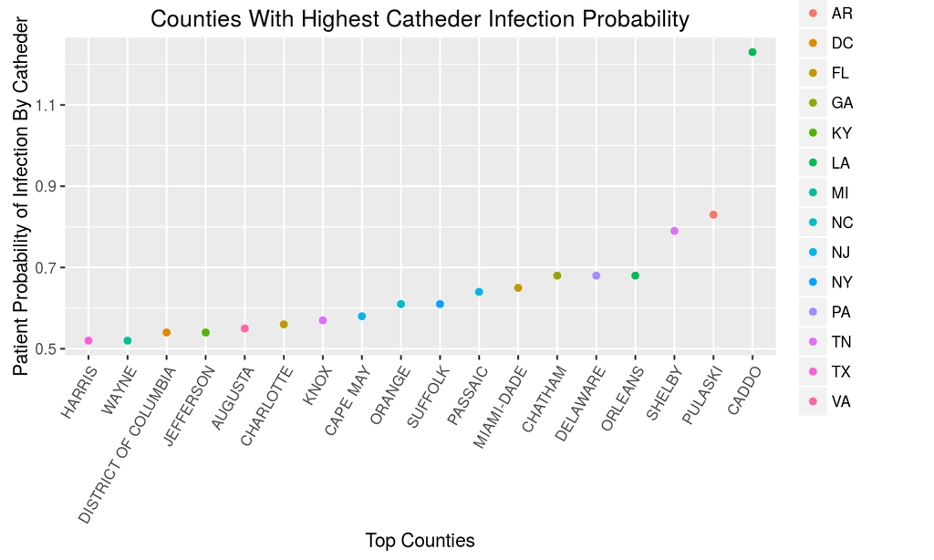

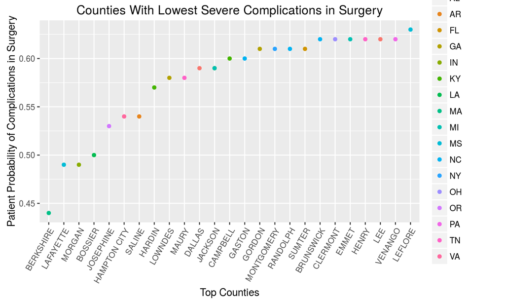

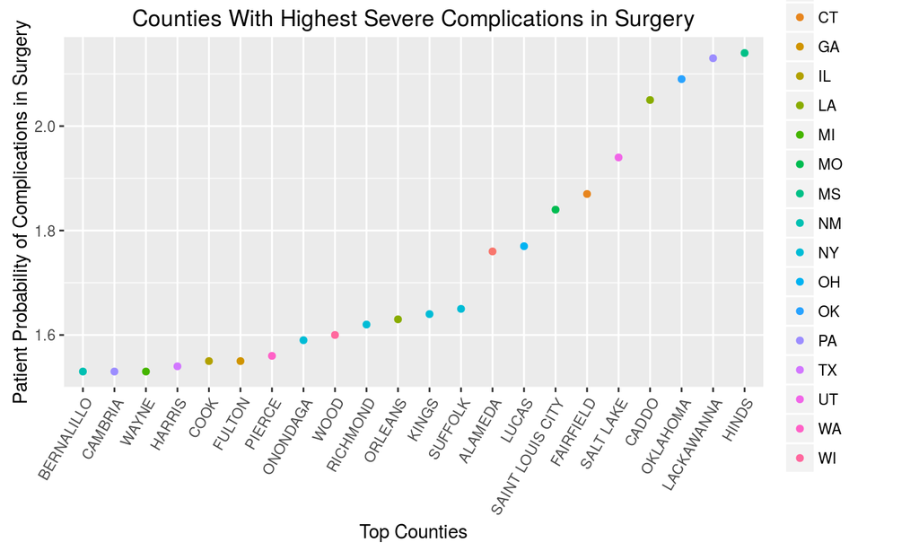

## Next Step

- What if we have other data on health?
- Expanding beyond top 20

## Mortality Rate

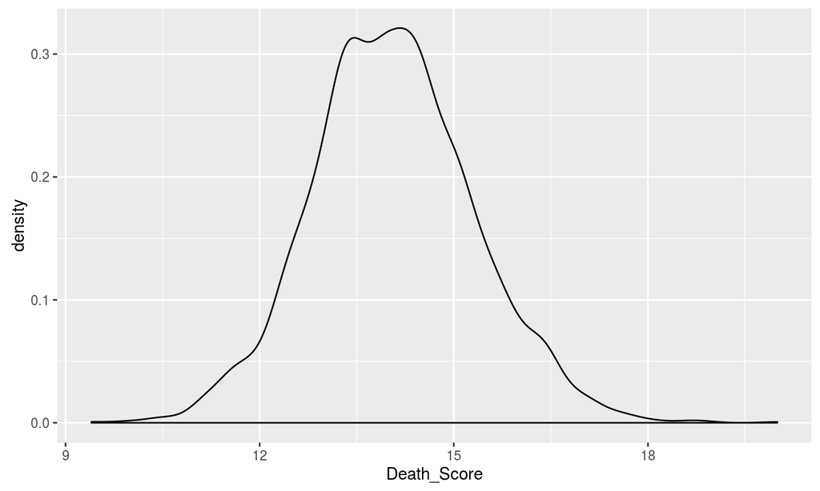

## Readmission Rate

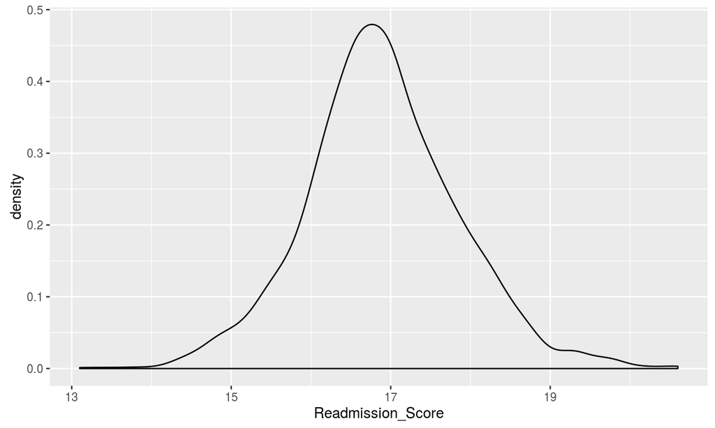

## Mortality Rate

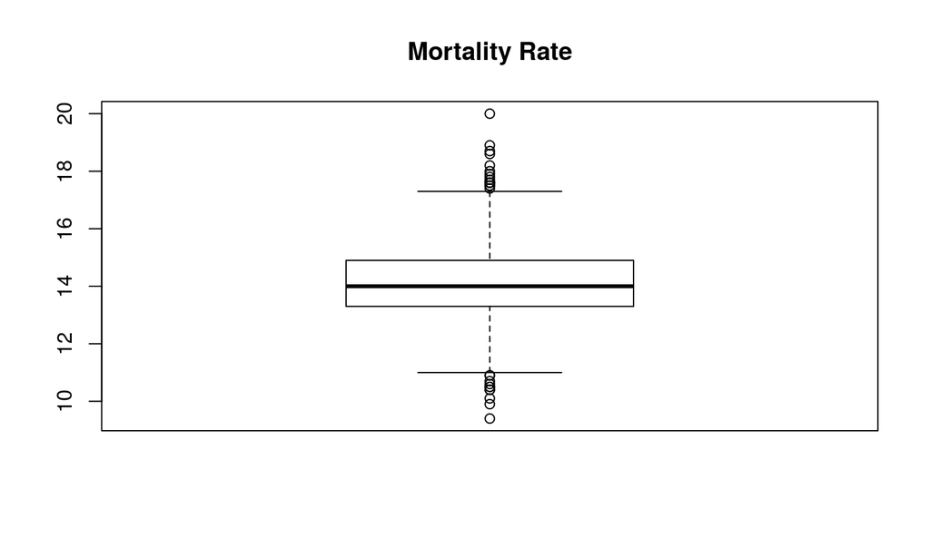

## Readmission Rate

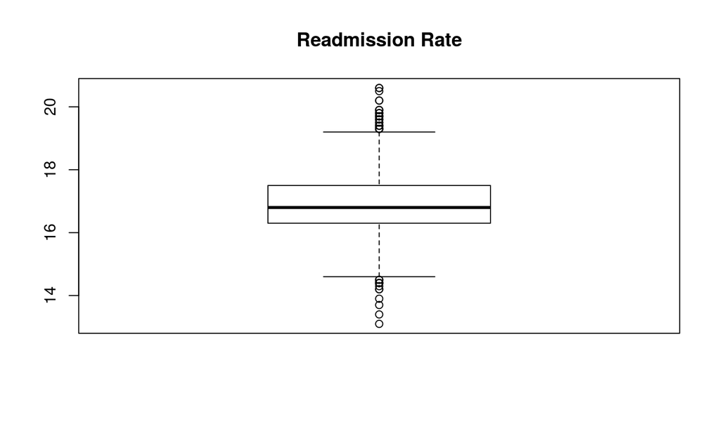

## Mortality VS Readmission (Average Hospital per County)

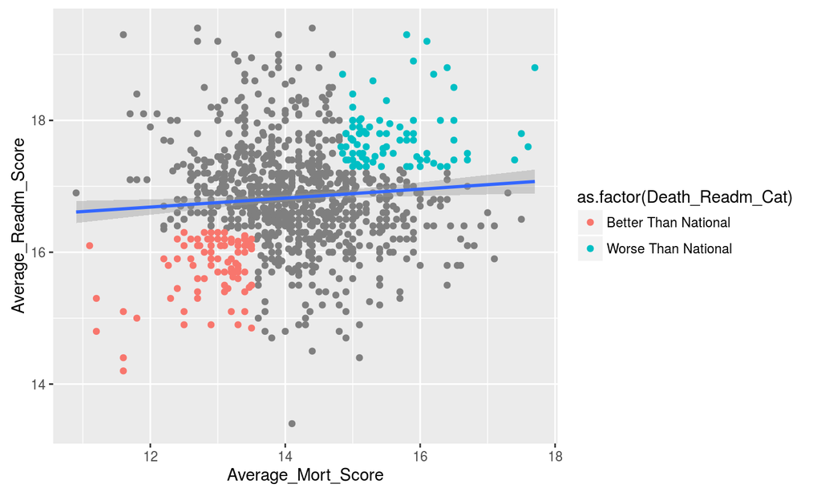

## Mortality VS Readmission per Hospital

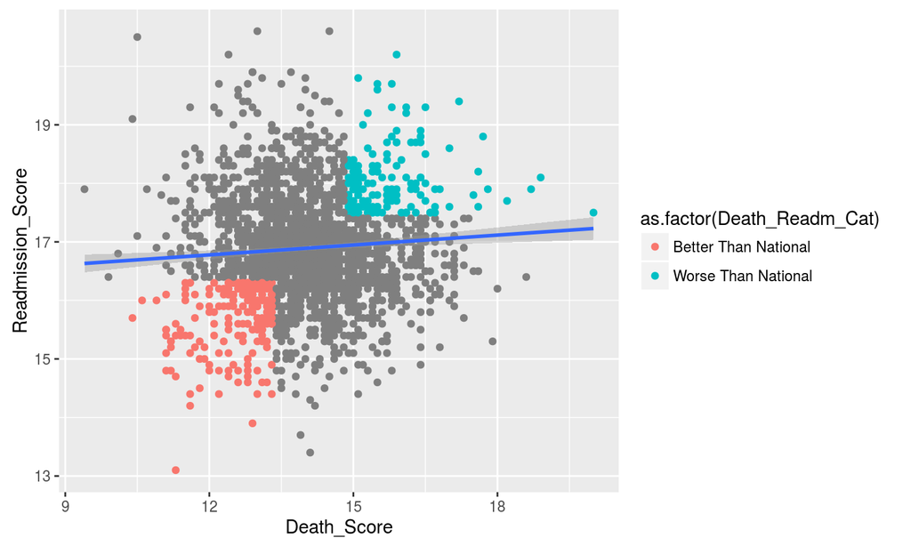

## Percent of Good Hospitals Vs Total Hospitals Per County

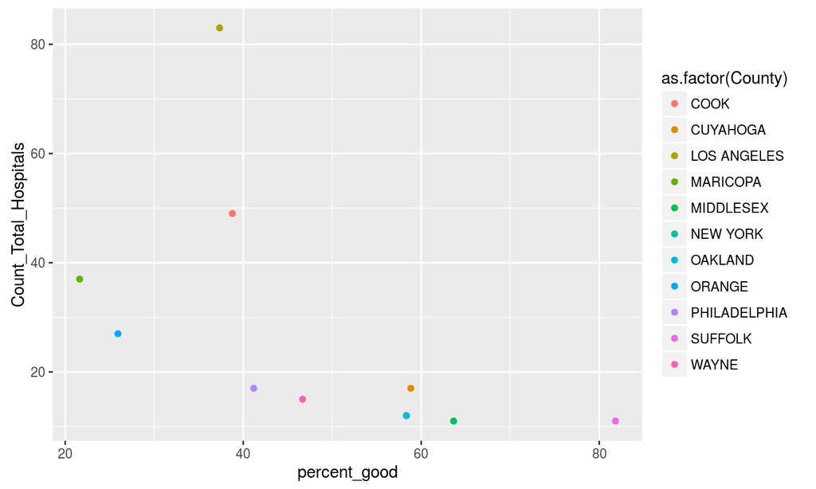

## Percent of Bad Hospitals Vs. Total Hospitals Per County

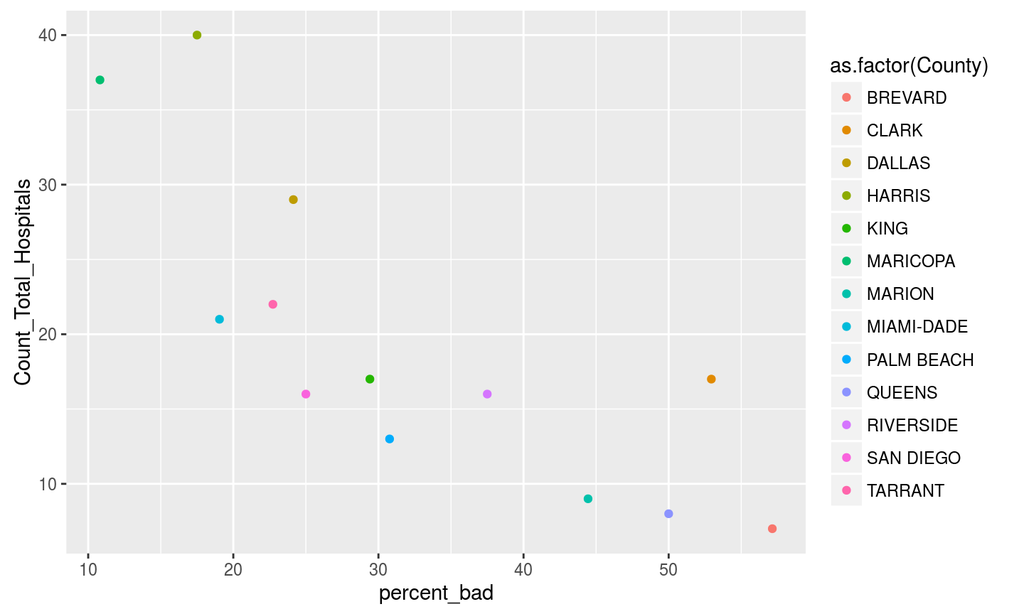

## Prevention

- Factors
  1. Nutrition
  2. Smoking

## Nutrition

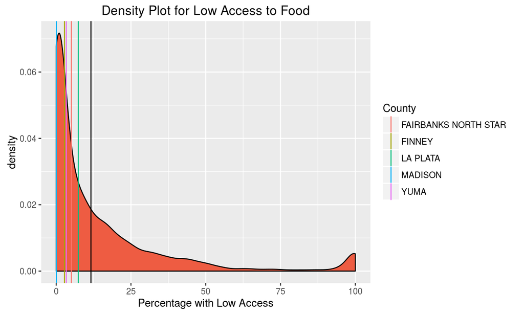

## Smoking

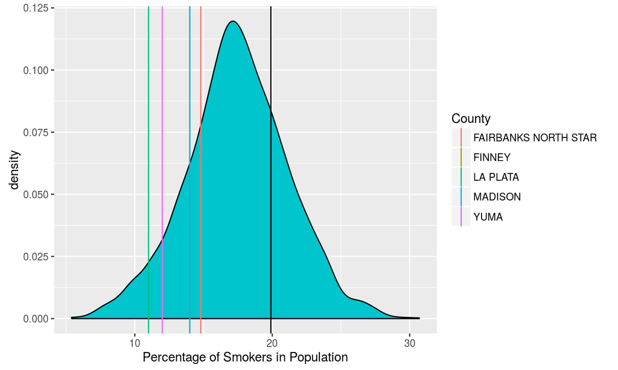

## Physical Inactivity VS Obesity

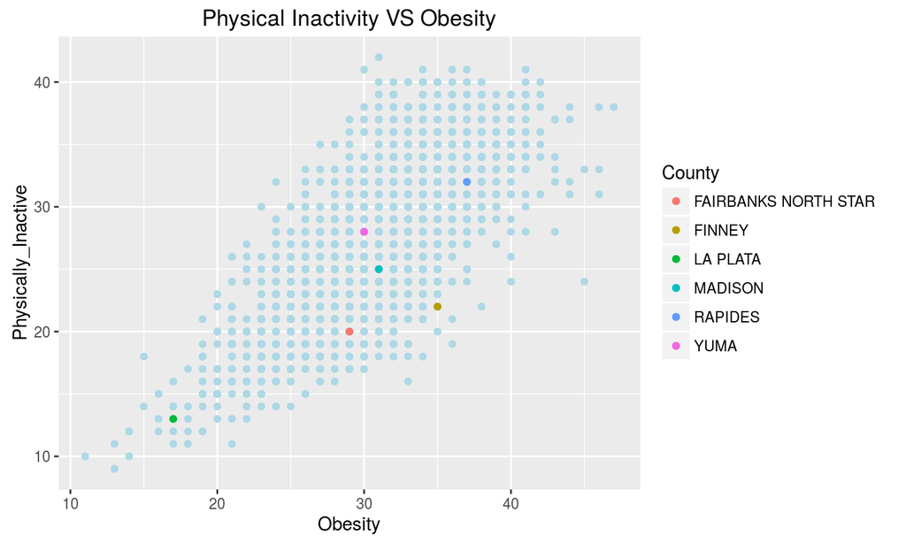